# Biscuit Boys Project Proposal

2024-03-08

## Team Members

- Claire Blackman
- Will Petty
- Ryan Helms
- Vedika Birla
- Max Van Fleet

## Dataset

### Description:

The data set includes 13900 images of melanoma lesions which are organized into folders of malignant and benign lesions. The dataset includes a train-test split. Each image consists of 224 x 224 pixels, and the author explains that this data was compiled from various sources. There was no additional data other than the images

### Location:

Our data set is titled 🔬Melanoma Cancer Image Dataset from Kaggle uploaded by the user Bhavesh Mittal. The link to the data set is https://www.kaggle.com/datasets/bhaveshmittal/melanoma-cancer-dataset.

## Motivation and Goals

Our initial goal/motivation was to select a topic related to healthcare, since that was a common thread among all of the group members. We were specifically interested in deepening our understanding of image classification, cancer research, and diagnoses. Given these interests we decided to use this melanoma data set, which is composed of just the images of the tumors without initial metadata. Since the data set is just images, our objective will be image classification without any additional data. Accuracy is important to us as well as trying to minimize the number of false negatives in cancer diagnosis. Implementing different penalization methods with the various models will be another part of our analysis. We chose to begin with this dataset to ensure we are not biting off more than we can chew, while leaving room to easily expand our scope into similar datasets if we exhaust our possible routes of examination.

## Exploratory Data Analysis

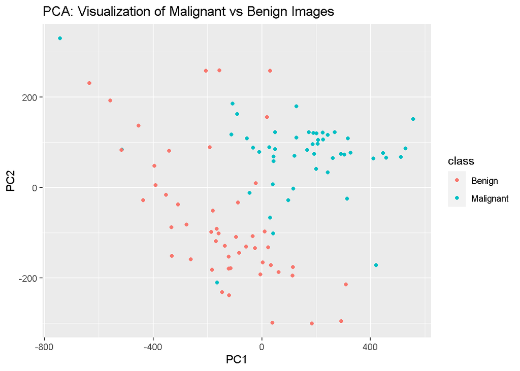

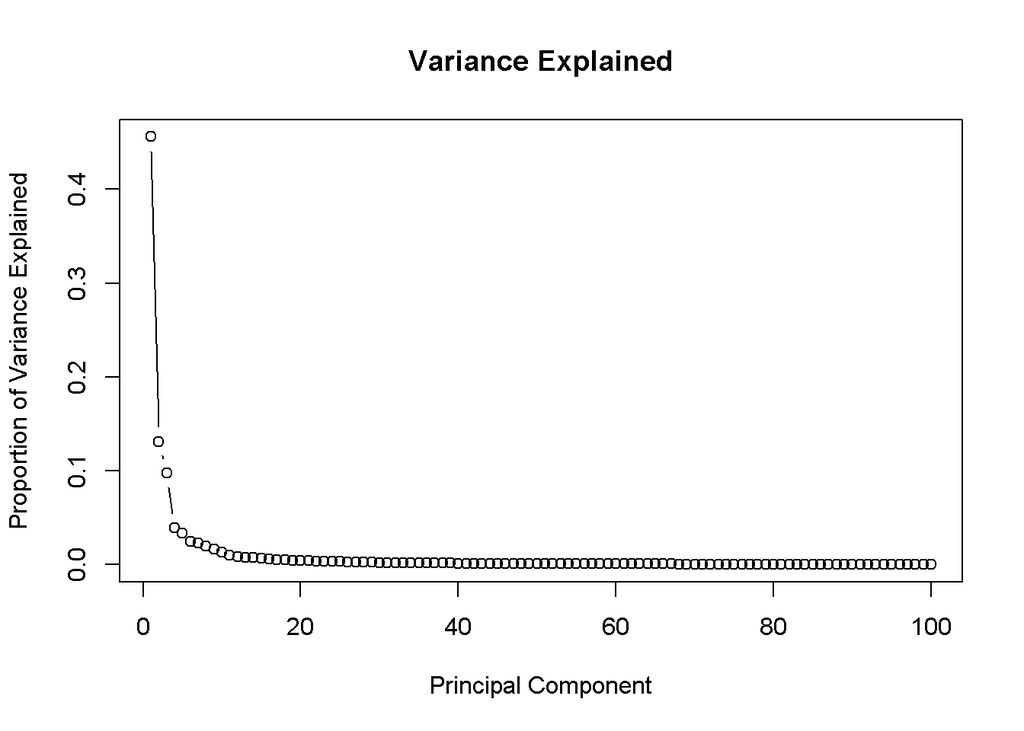

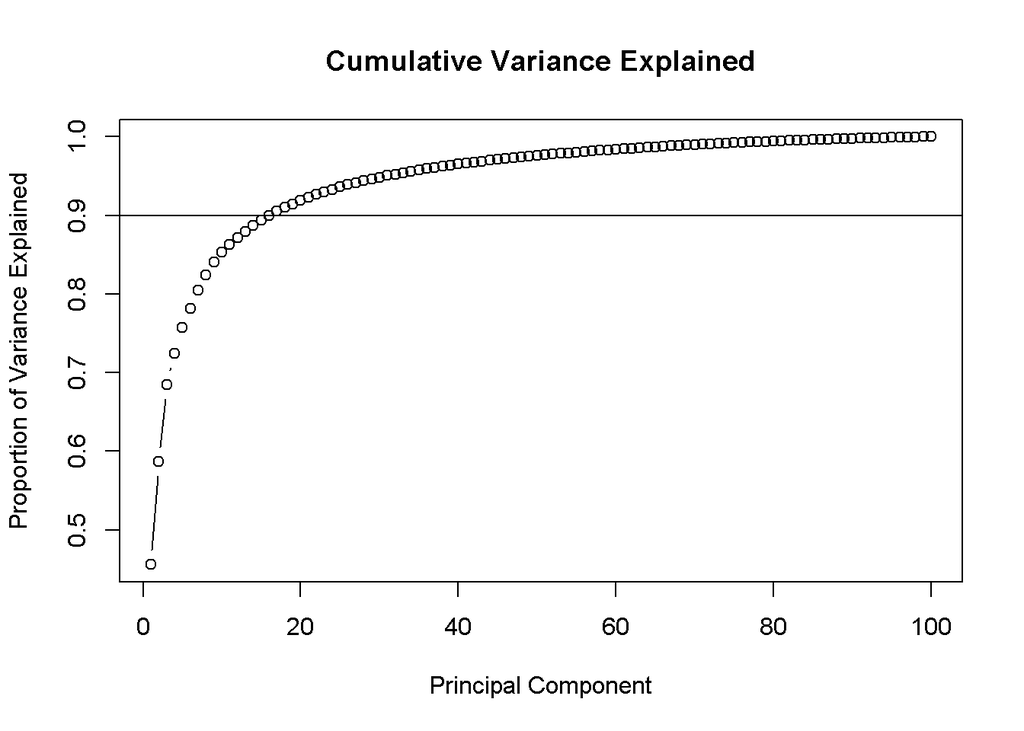

We performed some basic clustering analysis on various portions of the PCA scores, including the first 3, 17, 50, and 100 PCA scores. K-means with k = 2 saw its best performance by Adjusted Rand Index when applied to the first 50 PCA scores, with a 0.4298 ARI as its best observed performance. Below are plots of the kmeans output on the first 50 PCA scores, with the true class labels provided for reference.

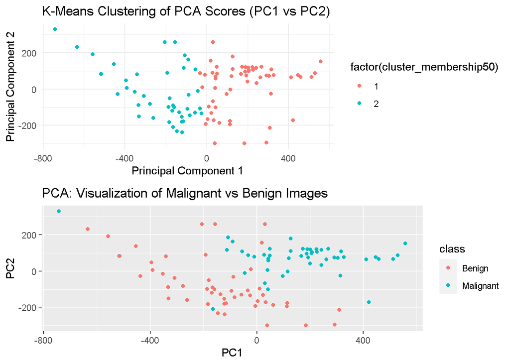

We also experimented with some hierarchical clustering methods. Of these, Ward.D linkage performed the best by Adjusted Rand Index, achieving a 0.30796 in the best observed repition. The lesser performance of hierarchical clustering methods suggest that there is not a hierarchical strucutre in our data, at least not one captured in the dimension reduced form. Below are plots comparing the performance of Ward.D linkage hierarchical clustering, cut into 2 classes, with the true class labels.

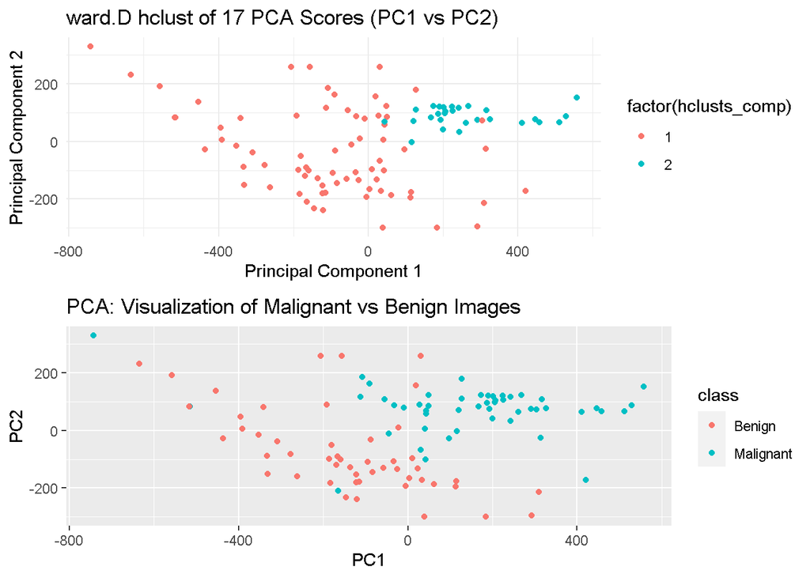

Finally, we loaded the first 1000 images of benign and malignant images from our train set, and attempted to train some basic classification techniques on the PCA scores of these data, which were then tested on the first 50 malignant and first 50 benign observations from the test set. This simple approach was surprisingly effective, achieving a 65% test accuracy. However, closer observation revealed that this test accuracy was primarily driven by a 78% accuracy on the benign images, with only a 52% accuracy on the malignant. We experimented with fitting a support vector machine model to this data, weighting misclassifications of the malignant errors more heavily than benign errors. We experimented with several weightings, with 5:1 weighting generating the best results. This merely reduced our accuracy in classifying benign images, but did not improve our ability to classify malignant cases.

## Preliminary Ideas on Techniques

Working with image data, it seems likely that an implementation of a convolutional neural network would lead to our best solution. We are not currently very familiar with CNN architecture, so we will have to learn more about them in order to implement one responsibly. The nature of this data as images makes data augmentation a very easy process to increase our training sample. Simple augmentation steps such as flipping images about the X or Y axis, or slight vertical or horizontal pixel shifts, should yield additional training samples of similar quality that will allow us to arrive at a more robust solution. If time permits, we would also like to experiment with generalizing our results to different image dimensions, as there are many similar datasets available across a wide array of image sizes.